# RW Simulations — Production & Comprehension

2025-11-28

```r
library(tidyverse)
library(brms)
library(ggpubr)
library(ggh4x)
library(arm)
library(ndl)
library(future)
library(future.apply)
library(furrr)
source("RescorlaLogistic.R")

plan(multisession, workers = min(7L, (parallel::detectCores() - 4L) %/% 4L))
DATA_DIR <- normalizePath('../Data')

n_sims <- 100
```

```r
cond1 <- read_csv('../Conditions/Condition1.csv')
cond2 <- read_csv('../Conditions/Condition2.csv')
cond3 <- read_csv('../Conditions/Condition3.csv')
cond4 <- read_csv('../Conditions/Condition4.csv')
cond5 <- read_csv('../Conditions/Condition5.csv')
cond6 <- read_csv('../Conditions/Condition6.csv')
```

# Production RW Simulations

## Data Preparation

```r
make_prod_cue_table <- function(cond_df, freq_multiplier = 5) {
  cond_df %>%
    mutate(stem = orthoCoding(stem),
           type = case_when(
             suffix %in% c('dan','sil')   ~ 'big_pl',
             suffix == 'none'             ~ 'big_sg',
             suffix %in% c('nem','shoon') ~ 'dim_sg')) %>%
    mutate(key = paste0(stem, '_', type)) %>%
    group_by(key, suffix) %>%
    summarize(frequency = table(key), .groups = 'drop') %>%
    rename(Cues = key, Outcomes = suffix, Frequency = frequency) %>%
    mutate(Frequency = as.numeric(Frequency) * freq_multiplier) %>%
    uncount(Frequency) %>%
    mutate(Frequency = 1)
}

data_cond1_prod <- make_prod_cue_table(cond1)
data_cond2_prod <- make_prod_cue_table(cond2)
data_cond3_prod <- make_prod_cue_table(cond3)
data_cond4_prod <- make_prod_cue_table(cond4)
data_cond5_prod <- make_prod_cue_table(cond5)
data_cond6_prod <- make_prod_cue_table(cond6)
```

```r
data_prod <- read_csv('../Conditions/production_condition.csv') %>%
  mutate(stem = orthoCoding(prod_label),
         type = case_when(
           str_detect(file, 'dim_sg') ~ 'dim_sg',
           str_detect(file, '_2')     ~ 'big_pl',
           str_detect(file, 'dim_pl') ~ 'dim_pl'),
         row_id = row_number())
```

## Main RW Simulations

Each variant runs 100 simulations (averaged over random orderings) per condition, with the `sim` column preserved for CI band calculation.

### Standard Variant

Cues = stem bigrams + type label. Outcomes = suffix identity.

```r
std_matrices <- future_map(
  list(data_cond1_prod, data_cond2_prod, data_cond3_prod,
       data_cond4_prod, data_cond5_prod, data_cond6_prod),
  function(cond_data) {
    map_dfr(1:n_sims, function(i) {
      result <- as.data.frame(Rescorla(
        cuesOutcomes = cond_data[sample(1:nrow(cond_data)), ], logistic = T))
      rownames_to_column(result, var = 'cue') %>% mutate(sim = i)
    })
  })
data_cond1_rw_matrix <- std_matrices[[1]]
data_cond2_rw_matrix <- std_matrices[[2]]
data_cond3_rw_matrix <- std_matrices[[3]]
data_cond4_rw_matrix <- std_matrices[[4]]
data_cond5_rw_matrix <- std_matrices[[5]]
data_cond6_rw_matrix <- std_matrices[[6]]
```

```r
data_prod_sims <- map_dfr(1:n_sims, ~ mutate(data_prod, sim = .x))

make_prod_results <- function(data_prod_sim, rw_matrix, cond_num, flip_sign = FALSE) {
  data_prod_sim %>%
    mutate(key = paste0(stem, '_', type)) %>%
    dplyr::select(prod_condition, key, sim, row_id, prod_label, file, type) %>%
    group_by(sim) %>%
    mutate(row_id = row_number()) %>%
    ungroup() %>%
    separate_rows(key, sep = "_") %>%
    left_join(rw_matrix, by = c("key" = "cue", "sim")) %>%
    group_by(row_id, sim) %>%
    summarize(dan_activations   = sum(dan,   na.rm = T),
              sil_activations   = sum(sil,   na.rm = T),
              nem_activations   = sum(nem,   na.rm = T),
              shoon_activations = sum(shoon, na.rm = T),
              .groups = 'drop') %>%
    left_join(data_prod_sim %>% group_by(sim) %>% mutate(row_id = row_number()),
              by = c("row_id", "sim")) %>%
    mutate(condition = cond_num,
           freq_minus_infreq = if (flip_sign) nem_activations - dan_activations
                               else           dan_activations - nem_activations)
}

data_prod_results_cond1 <- make_prod_results(data_prod_sims, data_cond1_rw_matrix, 1)
data_prod_results_cond2 <- make_prod_results(data_prod_sims, data_cond2_rw_matrix, 2)
data_prod_results_cond3 <- make_prod_results(data_prod_sims, data_cond3_rw_matrix, 3)
data_prod_results_cond4 <- make_prod_results(data_prod_sims, data_cond4_rw_matrix, 4, flip_sign = TRUE)
data_prod_results_cond5 <- make_prod_results(data_prod_sims, data_cond5_rw_matrix, 5, flip_sign = TRUE)
data_prod_results_cond6 <- make_prod_results(data_prod_sims, data_cond6_rw_matrix, 6, flip_sign = TRUE)

data_all_conds_logistic2 <- rbind(
  data_prod_results_cond1, data_prod_results_cond2, data_prod_results_cond3,
  data_prod_results_cond4, data_prod_results_cond5, data_prod_results_cond6)
```

```r
data_all_conds_logistic2_summary <- data_all_conds_logistic2 %>%
  mutate(meaning = case_when(
    type == 'dim_sg' ~ 'original',
    type == 'big_pl' ~ 'original',
    type == 'dim_pl' ~ 'novel')) %>%
  mutate(condition = case_when(
    condition %in% c(1,4) ~ 1,
    condition %in% c(2,5) ~ 2,
    condition %in% c(3,6) ~ 3)) %>%
  group_by(meaning, prod_condition, condition, sim) %>%
  summarize(mean_freq_diff = mean(freq_minus_infreq), .groups = 'keep') %>%
  group_by(meaning, prod_condition, condition) %>%
  summarize(mean_freq_diff_v2 = mean(mean_freq_diff),
            ci2.5  = quantile(mean_freq_diff, 0.025, na.rm = T),
            ci97.5 = quantile(mean_freq_diff, 0.975, na.rm = T),
            .groups = 'keep')
```

### Configural Cues

Cues = concatenated stem_meaning tags (e.g., “blik_big.pl”). Forces stem-meaning bindings.

```r
add_configural_suffix <- function(cond_data) {
  cond_data %>%
    mutate(Cues = case_when(
      str_ends(Cues, "big_pl") ~ paste0(Cues, "_big.pl"),
      str_ends(Cues, "big_sg") ~ paste0(Cues, "_big.sg"),
      str_ends(Cues, "dim_sg") ~ paste0(Cues, "_dim.sg"),
      TRUE ~ Cues))
}

data_cond1_configural <- add_configural_suffix(data_cond1_prod)
data_cond2_configural <- add_configural_suffix(data_cond2_prod)
data_cond3_configural <- add_configural_suffix(data_cond3_prod)
data_cond4_configural <- add_configural_suffix(data_cond4_prod)
data_cond5_configural <- add_configural_suffix(data_cond5_prod)
data_cond6_configural <- add_configural_suffix(data_cond6_prod)
```

```r
configural_matrices <- future_map(
  list(data_cond1_configural, data_cond2_configural, data_cond3_configural,
       data_cond4_configural, data_cond5_configural, data_cond6_configural),
  function(cond_data) {
    map_dfr(1:n_sims, function(i) {
      result <- as.data.frame(Rescorla(
        cuesOutcomes = cond_data[sample(1:nrow(cond_data)), ], logistic = T))
      rownames_to_column(result, var = 'cue') %>% mutate(sim = i)
    })
  })
data_cond1_rw_matrix_configural <- configural_matrices[[1]]
data_cond2_rw_matrix_configural <- configural_matrices[[2]]
data_cond3_rw_matrix_configural <- configural_matrices[[3]]
data_cond4_rw_matrix_configural <- configural_matrices[[4]]
data_cond5_rw_matrix_configural <- configural_matrices[[5]]
data_cond6_rw_matrix_configural <- configural_matrices[[6]]
```

```r
# For configural cues, type labels are remapped to include the dot notation
data_prod_cfg <- data_prod %>%
  mutate(type = case_when(
    type == 'dim_sg' ~ 'dim_sg_dim.sg',
    type == 'big_pl' ~ 'big_pl_big.pl',
    type == 'dim_pl' ~ 'dim_pl'))

data_prod_cfg_sims <- map_dfr(1:n_sims, ~ mutate(data_prod_cfg, sim = .x))

make_prod_results_cfg <- function(data_prod_sim, rw_matrix, cond_num, flip_sign = FALSE) {
  data_prod_sim %>%
    mutate(key = paste0(stem, '_', type)) %>%
    dplyr::select(prod_condition, key, sim, row_id, prod_label, file, type) %>%
    group_by(sim) %>% mutate(row_id = row_number()) %>% ungroup() %>%
    separate_rows(key, sep = "_") %>%
    left_join(rw_matrix, by = c("key" = "cue", "sim")) %>%
    group_by(row_id, sim) %>%
    summarize(dan_activations   = sum(dan,   na.rm = T),
              sil_activations   = sum(sil,   na.rm = T),
              nem_activations   = sum(nem,   na.rm = T),
              shoon_activations = sum(shoon, na.rm = T), .groups = 'drop') %>%
    left_join(data_prod_sim %>% group_by(sim) %>% mutate(row_id = row_number()),
              by = c("row_id", "sim")) %>%
    mutate(condition = cond_num,
           freq_minus_infreq = if (flip_sign) nem_activations - dan_activations
                               else           dan_activations - nem_activations)
}

cfg_cond1 <- make_prod_results_cfg(data_prod_cfg_sims, data_cond1_rw_matrix_configural, 1)
cfg_cond2 <- make_prod_results_cfg(data_prod_cfg_sims, data_cond2_rw_matrix_configural, 2)
cfg_cond3 <- make_prod_results_cfg(data_prod_cfg_sims, data_cond3_rw_matrix_configural, 3)
cfg_cond4 <- make_prod_results_cfg(data_prod_cfg_sims, data_cond4_rw_matrix_configural, 4, flip_sign = TRUE)
cfg_cond5 <- make_prod_results_cfg(data_prod_cfg_sims, data_cond5_rw_matrix_configural, 5, flip_sign = TRUE)
cfg_cond6 <- make_prod_results_cfg(data_prod_cfg_sims, data_cond6_rw_matrix_configural, 6, flip_sign = TRUE)

data_all_conds_configural <- rbind(cfg_cond1, cfg_cond2, cfg_cond3,
                                   cfg_cond4, cfg_cond5, cfg_cond6)
```

### Configural + Modified Alpha

Configural cues with elevated alpha for semantic cues (dim, pl, big, sg).

```r
semantic_cues <- c('dim', 'pl', 'big', 'sg', 'big.pl', 'big.sg', 'dim.sg', 'dim.pl')

mod_alpha_matrices <- future_map(
  list(data_cond1_configural, data_cond2_configural, data_cond3_configural,
       data_cond4_configural, data_cond5_configural, data_cond6_configural),
  function(cond_data) {
    map_dfr(1:n_sims, function(i) {
      result <- as.data.frame(Rescorla_modified_alpha_for_semantic_cues(
        cuesOutcomes = cond_data[sample(1:nrow(cond_data)), ], logistic = T))
      rownames_to_column(result, var = 'cue') %>% mutate(sim = i)
    })
  })
data_cond1_rw_matrix_configural_mod_alpha <- mod_alpha_matrices[[1]]
data_cond2_rw_matrix_configural_mod_alpha <- mod_alpha_matrices[[2]]
data_cond3_rw_matrix_configural_mod_alpha <- mod_alpha_matrices[[3]]
data_cond4_rw_matrix_configural_mod_alpha <- mod_alpha_matrices[[4]]
data_cond5_rw_matrix_configural_mod_alpha <- mod_alpha_matrices[[5]]
data_cond6_rw_matrix_configural_mod_alpha <- mod_alpha_matrices[[6]]
```

```r
mod_cond1 <- make_prod_results_cfg(data_prod_cfg_sims, data_cond1_rw_matrix_configural_mod_alpha, 1)
mod_cond2 <- make_prod_results_cfg(data_prod_cfg_sims, data_cond2_rw_matrix_configural_mod_alpha, 2)
mod_cond3 <- make_prod_results_cfg(data_prod_cfg_sims, data_cond3_rw_matrix_configural_mod_alpha, 3)
mod_cond4 <- make_prod_results_cfg(data_prod_cfg_sims, data_cond4_rw_matrix_configural_mod_alpha, 4, flip_sign = TRUE)
mod_cond5 <- make_prod_results_cfg(data_prod_cfg_sims, data_cond5_rw_matrix_configural_mod_alpha, 5, flip_sign = TRUE)
mod_cond6 <- make_prod_results_cfg(data_prod_cfg_sims, data_cond6_rw_matrix_configural_mod_alpha, 6, flip_sign = TRUE)

data_all_conds_configural_modified_alpha <- rbind(mod_cond1, mod_cond2, mod_cond3,
                                                   mod_cond4, mod_cond5, mod_cond6)
```

## Statistical Models for Paper

```r
human_data_prod <- read_csv('../Data/data_prod_no_sil_shoon.csv')
data_all_conds_for_comparison <- data_all_conds_logistic2 %>%
  rename(picture_meaning  = type,
         resp_stem        = prod_label,
         stem_condition   = prod_condition,
         original_condition = condition)

# Average RW predictions over sims before joining to avoid 100x row duplication
data_rw_avg_prod <- data_all_conds_for_comparison %>%
  group_by(original_condition, stem_condition, resp_stem, picture_meaning) %>%
  summarize(freq_minus_infreq = mean(freq_minus_infreq),
            dan_activations   = mean(dan_activations),
            nem_activations   = mean(nem_activations),
            sil_activations   = mean(sil_activations),
            shoon_activations = mean(shoon_activations),
            .groups = 'drop')

human_data_plus_rw_prod <- human_data_prod %>%
  left_join(data_rw_avg_prod)
```

[output not shown]

```r
options(contrasts = c("contr.treatment","contr.treatment"))

priors_rw_prod <- c(
  prior(student_t(3, 0, 1), class = 'Intercept'),
  prior(student_t(3, 0, 1), class = 'b'),
  prior(student_t(3, 0, 1), class = 'sd'))

f_human_rw_preds <- future({
  brm(frequency ~ freq_minus_infreq + (1 | participant) + (1 | resp_stem),
      data = human_data_plus_rw_prod, family = bernoulli(link = 'logit'),
      iter = 15000, warmup = 7500, chains = 4, cores = 4,
      prior = priors_rw_prod, save_pars = save_pars(all = TRUE), seed = 964,
      file = file.path(DATA_DIR, 'model_human_rw_preds'))
})

data_prod_results_for_stem_suffix_vary <- data_all_conds_logistic2 %>%
  dplyr::select(condition, freq_minus_infreq, prod_condition,
                prod_label, type) %>%
  rename(stem_condition     = prod_condition,
         picture_meaning    = type,
         original_condition = condition,
         resp_stem          = prod_label) %>%
  group_by(resp_stem, original_condition, stem_condition, picture_meaning) %>%
  summarize(freq_minus_infreq = mean(freq_minus_infreq), .groups = 'drop')

human_data_plus_rw_stem_suffix <- human_data_prod %>%
  left_join(data_prod_results_for_stem_suffix_vary)
```

[output not shown]

```r
human_data_plus_rw_stem_suffix$condition <- factor(
  human_data_plus_rw_stem_suffix$condition, levels = c(3, 1, 2))

f_rw_stem_suffix_vary <- future({
  brm(frequency ~ freq_minus_infreq + (1 | participant) + (1 | resp_stem),
      data = human_data_plus_rw_stem_suffix, family = bernoulli(link = 'logit'),
      iter = 14000, warmup = 7000, chains = 4, cores = 4,
      prior = priors_rw_prod, control = list(adapt_delta = 0.99),
      save_pars = save_pars(all = TRUE), seed = 964,
      file = file.path(DATA_DIR, 'model_prod_rw_stem_suffix_vary'))
})

f_rw_stem_suffix_by_cond <- future({
  brm(frequency ~ freq_minus_infreq + condition +
        freq_minus_infreq:condition + (1 | participant) + (1 | resp_stem),
      data = human_data_plus_rw_stem_suffix, family = bernoulli(link = 'logit'),
      iter = 14000, warmup = 7000, chains = 4, cores = 4,
      prior = priors_rw_prod, control = list(adapt_delta = 0.99),
      save_pars = save_pars(all = TRUE), seed = 964,
      file = file.path(DATA_DIR, 'model_prod_rw_stem_suffix_vary_by_condition'))
})

f_rw_stem_suffix_no_int <- future({
  brm(frequency ~ freq_minus_infreq + condition + (1 | participant) + (1 | resp_stem),
      data = human_data_plus_rw_stem_suffix, family = bernoulli(link = 'logit'),
      iter = 14000, warmup = 7000, chains = 4, cores = 4,
      prior = priors_rw_prod, control = list(adapt_delta = 0.99),
      save_pars = save_pars(all = TRUE), seed = 964,
      file = file.path(DATA_DIR, 'model_prod_rw_stem_suffix_vary_no_interaction'))
})

human_data_plus_rw_stem_suffix$meaning <- factor(
  human_data_plus_rw_stem_suffix$meaning)
contrasts(human_data_plus_rw_stem_suffix$meaning) <-
  contr.sum(levels(human_data_plus_rw_stem_suffix$meaning))
human_data_plus_rw_stem_suffix$stem_condition <- factor(
  human_data_plus_rw_stem_suffix$stem_condition, levels = c('novel','familiar'))
contrasts(human_data_plus_rw_stem_suffix$stem_condition) <-
  contr.sum(levels(human_data_plus_rw_stem_suffix$stem_condition))

f_rw_by_cond_orig_preds <- future({
  brm(frequency ~ condition*meaning*stem_condition +
        freq_minus_infreq + freq_minus_infreq:condition +
        (1 | participant) + (1 | resp_stem),
      data = human_data_plus_rw_stem_suffix, family = bernoulli(link = 'logit'),
      iter = 14000, warmup = 7000, chains = 4, cores = 4,
      prior = priors_rw_prod, control = list(adapt_delta = 0.99),
      save_pars = save_pars(all = TRUE), seed = 964,
      file = file.path(DATA_DIR, 'model_prod_rw_stem_suffix_vary_by_condition_original_preds'))
})

model_human_rw_preds                           <- value(f_human_rw_preds)
model_prod_rw_stem_suffix_vary                 <- value(f_rw_stem_suffix_vary)
model_prod_rw_stem_suffix_vary_by_condition    <- value(f_rw_stem_suffix_by_cond)
model_prod_rw_stem_suffix_vary_no_interaction  <- value(f_rw_stem_suffix_no_int)
model_prod_rw_stem_suffix_vary_by_condition_original_preds <- value(f_rw_by_cond_orig_preds)

fixef(model_prod_rw_stem_suffix_vary)
```

```
##                    Estimate Est.Error      Q2.5     Q97.5
## Intercept         -2.429700 0.6130131 -3.638170 -1.223445
## freq_minus_infreq  9.625008 0.1894989  9.260691  9.998999
```

```r
model_prod_rw_stem_suffix_vary_by_condition <-
  add_criterion(model_prod_rw_stem_suffix_vary_by_condition, 'loo')
model_prod_rw_stem_suffix_vary <-
  add_criterion(model_prod_rw_stem_suffix_vary, 'loo')
model_prod_rw_stem_suffix_vary_by_condition_original_preds <-
  add_criterion(model_prod_rw_stem_suffix_vary_by_condition_original_preds, 'loo')
model_prod_rw_stem_suffix_vary_no_interaction <-
  add_criterion(model_prod_rw_stem_suffix_vary_no_interaction, 'loo')

loo_compare(model_prod_rw_stem_suffix_vary,
            model_prod_rw_stem_suffix_vary_by_condition,
            model_prod_rw_stem_suffix_vary_no_interaction,
            model_prod_rw_stem_suffix_vary_by_condition_original_preds)
```

```
##                                                            elpd_diff se_diff
## model_prod_rw_stem_suffix_vary_by_condition_original_preds    0.0       0.0
## model_prod_rw_stem_suffix_vary_by_condition                -579.4      29.4
## model_prod_rw_stem_suffix_vary                             -661.4      34.4
## model_prod_rw_stem_suffix_vary_no_interaction              -664.3      34.6
```

## Paper Figure

```r
data_all_conds_logistic2_plot <- data_all_conds_logistic2 %>%
  mutate(meaning = case_when(
    type %in% c('dim_sg','big_pl') ~ 'original',
    type == 'dim_pl'               ~ 'novel')) %>%
  mutate(condition = case_when(
    condition %in% c(1,4) ~ 1,
    condition %in% c(2,5) ~ 2,
    condition %in% c(3,6) ~ 3)) %>%
  group_by(meaning, prod_condition, condition, sim) %>%
  summarize(mean_freq_diff = mean(freq_minus_infreq), .groups = 'keep') %>%
  group_by(meaning, prod_condition, condition) %>%
  summarize(mean_freq_diff_v2 = mean(mean_freq_diff),
            ci2.5  = quantile(mean_freq_diff, 0.025, na.rm = T),
            ci97.5 = quantile(mean_freq_diff, 0.975, na.rm = T), .groups = 'keep')

data_all_conds_logistic2_configural_modified_alpha_plot <-
  data_all_conds_configural_modified_alpha %>%
  mutate(meaning = case_when(
    type %in% c('dim_sg_dim.sg','big_pl_big.pl') ~ 'original',
    type == 'dim_pl'                              ~ 'novel')) %>%
  mutate(condition = case_when(
    condition %in% c(1,4) ~ 1,
    condition %in% c(2,5) ~ 2,
    condition %in% c(3,6) ~ 3)) %>%
  group_by(meaning, prod_condition, condition, sim) %>%
  summarize(mean_freq_diff = mean(freq_minus_infreq), .groups = 'keep') %>%
  group_by(meaning, prod_condition, condition) %>%
  summarize(mean_freq_diff_v2 = mean(mean_freq_diff),
            ci2.5  = quantile(mean_freq_diff, 0.025, na.rm = T),
            ci97.5 = quantile(mean_freq_diff, 0.975, na.rm = T), .groups = 'keep')

data_configural_plot <- data_all_conds_configural %>%
  mutate(meaning = case_when(
    type %in% c('dim_sg_dim.sg','big_pl_big.pl') ~ 'original',
    type == 'dim_pl'                              ~ 'novel')) %>%
  mutate(condition = case_when(
    condition %in% c(1,4) ~ 1,
    condition %in% c(2,5) ~ 2,
    condition %in% c(3,6) ~ 3)) %>%
  group_by(meaning, prod_condition, condition, sim) %>%
  summarize(mean_freq_diff = mean(freq_minus_infreq), .groups = 'keep') %>%
  group_by(meaning, prod_condition, condition) %>%
  summarize(mean_freq_diff_v2 = mean(mean_freq_diff),
            ci2.5  = quantile(mean_freq_diff, 0.025, na.rm = T),
            ci97.5 = quantile(mean_freq_diff, 0.975, na.rm = T), .groups = 'keep')
```

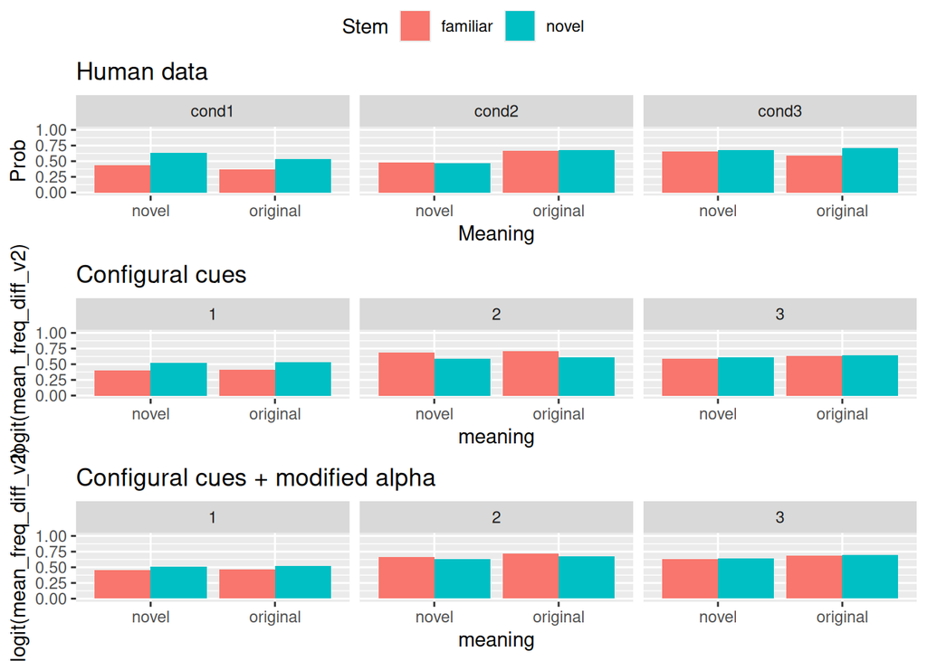

```r
rw_plot_configural <- ggplot(
  data = data_configural_plot,
  aes(x = meaning, y = invlogit(mean_freq_diff_v2), fill = prod_condition)) +
  geom_col(position = "dodge") +
  ylim(c(0,1)) +
  ggtitle('Configural cues') +
  facet_wrap(~condition)

rw_plot_configural_mod_alpha <- ggplot(
  data = data_all_conds_logistic2_configural_modified_alpha_plot,
  aes(x = meaning, y = invlogit(mean_freq_diff_v2), fill = prod_condition)) +
  geom_col(position = "dodge") +
  ylim(c(0,1)) +
  ggtitle('Configural cues + modified alpha') +
  facet_wrap(~condition)

fixed_effects_df <- read_csv('../Data/fixed_effects_df_all.csv') %>%
  filter(Task == 'prod')
observed_estimates_plot <- ggplot(
  data = fixed_effects_df,
  aes(x = Meaning, y = Prob, fill = Stem)) +
  geom_col(position = "dodge") +
  ylim(c(0,1)) +
  ggtitle('Human data') +
  facet_wrap(~Condition)

ggarrange(observed_estimates_plot, rw_plot_configural, rw_plot_configural_mod_alpha,
          nrow = 3, common.legend = TRUE)
```

## Further Exploration

### Alpha Changed But No Configural Cues

Modified alpha applied to standard (non-configural) cues — controls for the alpha change alone vs. the configural cue structure.

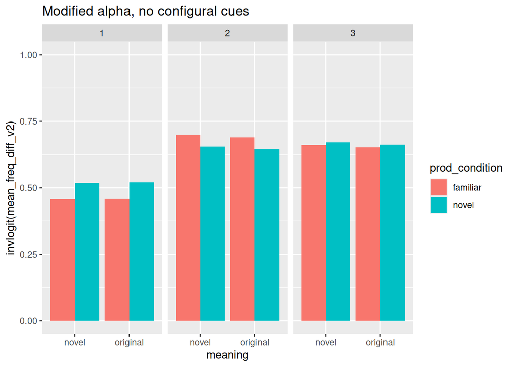

```r
non_cfg_matrices <- future_map(
  list(data_cond1_prod, data_cond2_prod, data_cond3_prod,
       data_cond4_prod, data_cond5_prod, data_cond6_prod),
  function(cond_data) {
    map_dfr(1:n_sims, function(i) {
      result <- as.data.frame(Rescorla_modified_alpha_for_semantic_cues(
        cuesOutcomes = cond_data[sample(1:nrow(cond_data)), ], logistic = T))
      rownames_to_column(result, var = 'cue') %>% mutate(sim = i)
    })
  })
data_cond1_rw_matrix_non_configural <- non_cfg_matrices[[1]]
data_cond2_rw_matrix_non_configural <- non_cfg_matrices[[2]]
data_cond3_rw_matrix_non_configural <- non_cfg_matrices[[3]]
data_cond4_rw_matrix_non_configural <- non_cfg_matrices[[4]]
data_cond5_rw_matrix_non_configural <- non_cfg_matrices[[5]]
data_cond6_rw_matrix_non_configural <- non_cfg_matrices[[6]]

nc1 <- make_prod_results(data_prod_sims, data_cond1_rw_matrix_non_configural, 1)
nc2 <- make_prod_results(data_prod_sims, data_cond2_rw_matrix_non_configural, 2)
nc3 <- make_prod_results(data_prod_sims, data_cond3_rw_matrix_non_configural, 3)
nc4 <- make_prod_results(data_prod_sims, data_cond4_rw_matrix_non_configural, 4, flip_sign = TRUE)
nc5 <- make_prod_results(data_prod_sims, data_cond5_rw_matrix_non_configural, 5, flip_sign = TRUE)
nc6 <- make_prod_results(data_prod_sims, data_cond6_rw_matrix_non_configural, 6, flip_sign = TRUE)

data_all_conds_non_configural <- rbind(nc1, nc2, nc3, nc4, nc5, nc6)

data_non_cfg_plot <- data_all_conds_non_configural %>%
  mutate(meaning = case_when(
    type %in% c('dim_sg','big_pl') ~ 'original',
    type == 'dim_pl'               ~ 'novel')) %>%
  mutate(condition = case_when(
    condition %in% c(1,4) ~ 1,
    condition %in% c(2,5) ~ 2,
    condition %in% c(3,6) ~ 3)) %>%
  group_by(meaning, prod_condition, condition, sim) %>%
  summarize(mean_freq_diff = mean(freq_minus_infreq), .groups = 'keep') %>%
  group_by(meaning, prod_condition, condition) %>%
  summarize(mean_freq_diff_v2 = mean(mean_freq_diff),
            ci2.5  = quantile(mean_freq_diff, 0.025, na.rm = T),
            ci97.5 = quantile(mean_freq_diff, 0.975, na.rm = T), .groups = 'keep')

ggplot(data = data_non_cfg_plot,
       aes(x = meaning, y = invlogit(mean_freq_diff_v2), fill = prod_condition)) +
  geom_col(position = "dodge") +
  ylim(c(0,1)) +
  ggtitle('Modified alpha, no configural cues') +
  facet_wrap(~condition)
```

# Comprehension RW Simulations

## Data Preparation

For comprehension, cues are the full label (stem_suffix form) and outcomes are the meaning categories.

```r
make_comp_cue_table <- function(cond_df, freq_multiplier = 2) {
  cond_df %>%
    mutate(label = case_when(
      suffix != 'none' ~ paste0(stem, '_', suffix),
      suffix == 'none' ~ stem),
           type = case_when(
             suffix %in% c('dan','sil')   ~ 'big_pl',
             suffix == 'none'             ~ 'big_sg',
             suffix %in% c('nem','shoon') ~ 'dim_sg')) %>%
    mutate(key = label) %>%
    group_by(key, type) %>%
    summarize(frequency = table(key), .groups = 'drop') %>%
    rename(Cues = key, Outcomes = type, Frequency = frequency) %>%
    mutate(Frequency = as.numeric(Frequency) * freq_multiplier) %>%
    uncount(Frequency) %>%
    mutate(Frequency = 1)
}

data_cond1_comp <- make_comp_cue_table(cond1)
data_cond2_comp <- make_comp_cue_table(cond2)
data_cond3_comp <- make_comp_cue_table(cond3)
data_cond4_comp <- make_comp_cue_table(cond4)
data_cond5_comp <- make_comp_cue_table(cond5)
data_cond6_comp <- make_comp_cue_table(cond6)
```

```r
data_comp <- read_csv('../Conditions/comprehension_condition.csv') %>%
  mutate(label = case_when(
    suffix != 'none' ~ paste0(stem, '_', suffix),
    suffix == 'none' ~ stem),
    row_id = row_number())
```

## Main RW Simulations

Parameters Alpha=0.45, Beta=0.25 selected via grid search (see “Further Exploration” below).

```r
main_matrices <- future_map(
  list(data_cond1_comp, data_cond2_comp, data_cond3_comp,
       data_cond4_comp, data_cond5_comp, data_cond6_comp),
  function(cond_data) {
    map_dfr(1:n_sims, function(i) {
      result <- as.data.frame(Rescorla(
        Alpha = 0.45, Beta = 0.25,
        cuesOutcomes = cond_data[sample(1:nrow(cond_data)), ], logistic = T))
      rownames_to_column(result, var = 'cue') %>% mutate(sim = i)
    })
  })
data_cond1_comp_rw_matrix <- main_matrices[[1]]
data_cond2_comp_rw_matrix <- main_matrices[[2]]
data_cond3_comp_rw_matrix <- main_matrices[[3]]
data_cond4_comp_rw_matrix <- main_matrices[[4]]
data_cond5_comp_rw_matrix <- main_matrices[[5]]
data_cond6_comp_rw_matrix <- main_matrices[[6]]
```

```r
data_comp_sims <- map_dfr(1:n_sims, ~ mutate(data_comp, sim = .x))

make_comp_results <- function(data_comp_sim, rw_matrix, cond_num) {
  data_comp_sim %>%
    mutate(key = label) %>%
    dplyr::select(stem_condition, key, sim, row_id, suffix) %>%
    group_by(sim) %>% mutate(row_id = row_number()) %>% ungroup() %>%
    separate_rows(key, sep = "_") %>%
    left_join(rw_matrix, by = c("key" = "cue", "sim")) %>%
    group_by(row_id, sim) %>%
    summarize(big_activations = sum(big, na.rm = T),
              pl_activations  = sum(pl,  na.rm = T),
              dim_activations = sum(dim, na.rm = T),
              sg_activations  = sum(sg,  na.rm = T), .groups = 'drop') %>%
    left_join(data_comp_sim %>% group_by(sim) %>% mutate(row_id = row_number()),
              by = c("row_id", "sim")) %>%
    mutate(condition = cond_num,
           new_minus_old = case_when(
             suffix == 'dan' ~ (dim_activations + pl_activations) -
               (big_activations + pl_activations),
             suffix == 'nem' ~ (dim_activations + pl_activations) -
               (dim_activations + sg_activations)))
}

comp_cond1 <- make_comp_results(data_comp_sims, data_cond1_comp_rw_matrix, 1)
comp_cond2 <- make_comp_results(data_comp_sims, data_cond2_comp_rw_matrix, 2)
comp_cond3 <- make_comp_results(data_comp_sims, data_cond3_comp_rw_matrix, 3)
comp_cond4 <- make_comp_results(data_comp_sims, data_cond4_comp_rw_matrix, 4)
comp_cond5 <- make_comp_results(data_comp_sims, data_cond5_comp_rw_matrix, 5)
comp_cond6 <- make_comp_results(data_comp_sims, data_cond6_comp_rw_matrix, 6)

data_all_conds <- rbind(comp_cond1, comp_cond2, comp_cond3,
                        comp_cond4, comp_cond5, comp_cond6)
```

```r
human_data_comp <- read_csv('../Data/data_analysis_comprehension.csv')
# Recode to 3 comprehension conditions (fold 4-6 into 1-3)
data_all_conds_test <- data_all_conds %>%
  mutate(
    language = case_when(condition %in% c(1,2,3) ~ 'dan', condition %in% c(4,5,6) ~ 'nem'),
    frequency = ifelse(suffix == language, 1, 0),
    condition = case_when(
      condition == 4 ~ 1, condition == 5 ~ 2, condition == 6 ~ 3, TRUE ~ condition),
    condition_numeric = case_when(
      (condition == 1 & frequency == 1) | (condition == 3 & frequency == 1) ~ '12-12',
      (condition == 1 & frequency == 0) | (condition == 2 & frequency == 1) ~ '12-3',
      (condition == 2 & frequency == 0) | (condition == 3 & frequency == 0) ~ '3-3'))

data_all_conds_test$stem_condition <- factor(data_all_conds_test$stem_condition)
contrasts(data_all_conds_test$stem_condition) <-
  contr.sum(levels(data_all_conds_test$stem_condition))
data_all_conds_test$condition_numeric <- factor(
  data_all_conds_test$condition_numeric, levels = c('12-3', '12-12', '3-3'))

# For RW-as-predictor models: average over sims first to avoid duplicating human rows.
# Join on comprehension_label (no-underscore format matching the human data CSV).
data_rw_avg <- data_all_conds_test %>%
  group_by(comprehension_label, stem) %>%
  summarize(new_minus_old = mean(new_minus_old), .groups = 'drop')

human_data_plus_rw <- human_data_comp %>%
  left_join(data_rw_avg, by = "comprehension_label")
```

## Statistical Models for Paper

```r
priors_rw_comp <- c(
  prior(student_t(3, 0, 1), class = 'Intercept'),
  prior(student_t(3, 0, 1), class = 'b'),
  prior(student_t(3, 0, 1), class = 'sd'))

priors_rw_comp_b <- c(
  prior(student_t(3, 0, 0.5), class = 'Intercept'),
  prior(student_t(3, 0, 0.5), class = 'b'),
  prior(student_t(3, 0, 0.5), class = 'sd'))

human_data_plus_rw$meaning <- factor(human_data_plus_rw$meaning, levels = c(0, 1))
human_data_plus_rw$condition_numeric <- factor(
  human_data_plus_rw$condition_numeric, levels = c('12-3', '12-12', '3-3'))
human_data_plus_rw$stem_condition <- factor(human_data_plus_rw$stem_condition)
contrasts(human_data_plus_rw$stem_condition) <-
  contr.sum(levels(human_data_plus_rw$stem_condition))
```

```r
f_comp_rw <- future({
  brm(meaning ~ new_minus_old + (1 | participant) + (1 | stem),
      data = human_data_plus_rw, family = bernoulli(link = 'logit'),
      iter = 16000, warmup = 8000, chains = 4, cores = 4,
      prior = priors_rw_comp, save_pars = save_pars(all = TRUE),
      control = list(adapt_delta = 0.99), seed = 964,
      file = file.path(DATA_DIR, 'model_comprehension_numeric_rw'))
})

f_comp_rw_by_cond <- future({
  brm(meaning ~ condition_numeric*new_minus_old + (1 | participant) + (1 | stem),
      data = human_data_plus_rw, family = bernoulli(link = 'logit'),
      iter = 12000, warmup = 6000, chains = 4, cores = 4,
      prior = priors_rw_comp, save_pars = save_pars(all = TRUE),
      control = list(adapt_delta = 0.99), seed = 964,
      file = file.path(DATA_DIR, 'model_comprehension_numeric_rw_by_cond'))
})

f_comp_rw_stem <- future({
  brm(meaning ~ condition_numeric*stem_condition*new_minus_old + (1 | participant) + (1 | stem),
      data = human_data_plus_rw, family = bernoulli(link = 'logit'),
      iter = 20000, warmup = 10000, chains = 4, cores = 4,
      prior = priors_rw_comp, save_pars = save_pars(all = TRUE),
      control = list(adapt_delta = 0.99, max_treedepth = 15), seed = 964,
      file = file.path(DATA_DIR, 'model_comprehension_numeric_stem_rw'))
})

f_comp_humans <- future({
  brm(meaning ~ condition_numeric + (1 | participant) + (1 | stem),
      data = human_data_plus_rw, family = bernoulli(link = 'logit'),
      iter = 12000, warmup = 6000, chains = 4, cores = 4,
      prior = priors_rw_comp, save_pars = save_pars(all = TRUE),
      control = list(adapt_delta = 0.99), seed = 964,
      file = file.path(DATA_DIR, 'model_comprehension_numeric_humans'))
})

f_comp_humans_stem <- future({
  brm(meaning ~ condition_numeric*stem_condition + (1 | participant) + (1 | stem),
      data = human_data_plus_rw, family = bernoulli(link = 'logit'),
      iter = 46000, warmup = 23000, chains = 4, cores = 4,
      prior = priors_rw_comp, save_pars = save_pars(all = TRUE),
      control = list(adapt_delta = 0.999, max_treedepth = 20), seed = 964,
      file = file.path(DATA_DIR, 'model_comprehension_numeric_stem_humans'))
})

f_rw_by_stat <- future({
  brm(new_minus_old ~ condition_numeric*stem_condition + (1 | participant) + (1 | stem),
      data = human_data_plus_rw,
      iter = 8000, warmup = 4000, chains = 4, cores = 4,
      prior = priors_rw_comp_b, save_pars = save_pars(all = TRUE),
      seed = 964,
      file = file.path(DATA_DIR, 'model_rw_preds_by_statistical_preds_nsims'))
})

model_comprehension_numeric_rw          <- value(f_comp_rw)
model_comprehension_numeric_rw_by_cond  <- value(f_comp_rw_by_cond)
model_comprehension_numeric_stem_rw     <- value(f_comp_rw_stem)
model_comprehension_numeric_humans      <- value(f_comp_humans)
model_comprehension_numeric_stem_humans <- value(f_comp_humans_stem)
model_rw_preds_by_statistical_preds_nsims <- value(f_rw_by_stat)
fixef(model_comprehension_numeric_rw)
```

```
##               Estimate Est.Error     Q2.5    Q97.5
## Intercept     370.3943  25.22562 321.0025 420.2789
## new_minus_old 236.5076  16.05071 205.0307 268.2223
```

```r
fixef(model_comprehension_numeric_stem_rw)
```

```
##                                                          Estimate  Est.Error
## Intercept                                            393.88115995 26.6926349
## condition_numeric12M12                                 0.31371749  0.9760841
## condition_numeric3M3                                   0.65375197  1.1028692
## stem_condition1                                        0.36125872  3.0163904
## new_minus_old                                        254.34176915 17.1368908
## condition_numeric12M12:stem_condition1                -0.01998503  0.9415884
## condition_numeric3M3:stem_condition1                  -0.12455341  0.9662495
## condition_numeric12M12:new_minus_old                  -0.35795940  0.6275882
## condition_numeric3M3:new_minus_old                    -0.76669200  0.7088231
## stem_condition1:new_minus_old                        -14.91684274  2.2461389
## condition_numeric12M12:stem_condition1:new_minus_old  -0.04409418  0.6047378
## condition_numeric3M3:stem_condition1:new_minus_old    -0.02072216  0.6209568
##                                                            Q2.5       Q97.5
## Intercept                                            342.151729 446.7243950
## condition_numeric12M12                                -1.586162   2.3450479
## condition_numeric3M3                                  -1.395790   2.9591780
## stem_condition1                                       -3.124137   4.9376251
## new_minus_old                                        221.117935 288.3051011
## condition_numeric12M12:stem_condition1                -1.910881   1.8610856
## condition_numeric3M3:stem_condition1                  -2.102140   1.7597808
## condition_numeric12M12:new_minus_old                  -1.579565   0.9356890
## condition_numeric3M3:new_minus_old                    -2.095498   0.7131048
## stem_condition1:new_minus_old                        -18.006371 -11.3283005
## condition_numeric12M12:stem_condition1:new_minus_old  -1.255110   1.1597410
## condition_numeric3M3:stem_condition1:new_minus_old    -1.291505   1.1825205
```

```r
hypothesis(model_comprehension_numeric_rw_by_cond,
           "condition_numeric3M3 - condition_numeric12M12 > 0")
```

```
## Hypothesis Tests for class b:
##                 Hypothesis Estimate Est.Error CI.Lower CI.Upper Evid.Ratio
## 1 (condition_numeri... > 0     1.16      1.21    -0.78     3.16       4.92
##   Post.Prob Star
## 1      0.83
## ---
## 'CI': 90%-CI for one-sided and 95%-CI for two-sided hypotheses.
## '*': For one-sided hypotheses, the posterior probability exceeds 95%;
## for two-sided hypotheses, the value tested against lies outside the 95%-CI.
## Posterior probabilities of point hypotheses assume equal prior probabilities.
```

```r
model_comprehension_numeric_rw      <- add_criterion(model_comprehension_numeric_rw,      'loo')
```

```
## Automatically saving the model object in '/home/zhoughton/misc/Generalizability-Type-Token/Data/model_comprehension_numeric_rw.rds'
```

```r
model_comprehension_numeric_stem_rw <- add_criterion(model_comprehension_numeric_stem_rw, 'loo')
```

```
## Automatically saving the model object in '/home/zhoughton/misc/Generalizability-Type-Token/Data/model_comprehension_numeric_stem_rw.rds'
```

```r
model_comprehension_numeric_humans  <- add_criterion(model_comprehension_numeric_humans,  'loo')
```

```
## Automatically saving the model object in '/home/zhoughton/misc/Generalizability-Type-Token/Data/model_comprehension_numeric_humans.rds'
```

```r
model_comprehension_numeric_stem_humans <- add_criterion(model_comprehension_numeric_stem_humans, 'loo')
```

```
## Automatically saving the model object in '/home/zhoughton/misc/Generalizability-Type-Token/Data/model_comprehension_numeric_stem_humans.rds'
```

```r
model_comprehension_numeric_rw_by_cond  <- add_criterion(model_comprehension_numeric_rw_by_cond,  'loo')
```

```
## Automatically saving the model object in '/home/zhoughton/misc/Generalizability-Type-Token/Data/model_comprehension_numeric_rw_by_cond.rds'
```

```r
loo_compare(model_comprehension_numeric_rw,
            model_comprehension_numeric_stem_rw,
            model_comprehension_numeric_humans,
            model_comprehension_numeric_stem_humans,
            model_comprehension_numeric_rw_by_cond)
```

```
##                                         elpd_diff se_diff
## model_comprehension_numeric_stem_rw        0.0       0.0
## model_comprehension_numeric_rw           -84.6      13.0
## model_comprehension_numeric_rw_by_cond  -135.9      12.5
## model_comprehension_numeric_humans      -144.7      17.4
## model_comprehension_numeric_stem_humans -147.2      17.4
```

## Further Exploration

### Default Alpha Simulations

Standard RW parameters (default Alpha and Beta) for comparison against the tuned Alpha=0.45, Beta=0.25 model.

```r
default_matrices <- future_map(
  list(data_cond1_comp, data_cond2_comp, data_cond3_comp,
       data_cond4_comp, data_cond5_comp, data_cond6_comp),
  function(cond_data) {
    map_dfr(1:n_sims, function(i) {
      result <- as.data.frame(Rescorla(
        cuesOutcomes = cond_data[sample(1:nrow(cond_data)), ], logistic = T))
      rownames_to_column(result, var = 'cue') %>% mutate(sim = i)
    })
  })
data_cond1_rw_matrix_default <- default_matrices[[1]]
data_cond2_rw_matrix_default <- default_matrices[[2]]
data_cond3_rw_matrix_default <- default_matrices[[3]]
data_cond4_rw_matrix_default <- default_matrices[[4]]
data_cond5_rw_matrix_default <- default_matrices[[5]]
data_cond6_rw_matrix_default <- default_matrices[[6]]

d1 <- make_comp_results(data_comp_sims, data_cond1_rw_matrix_default, 1)
d2 <- make_comp_results(data_comp_sims, data_cond2_rw_matrix_default, 2)
d3 <- make_comp_results(data_comp_sims, data_cond3_rw_matrix_default, 3)
d4 <- make_comp_results(data_comp_sims, data_cond4_rw_matrix_default, 4)
d5 <- make_comp_results(data_comp_sims, data_cond5_rw_matrix_default, 5)
d6 <- make_comp_results(data_comp_sims, data_cond6_rw_matrix_default, 6)

data_all_conds_default <- rbind(d1, d2, d3, d4, d5, d6)

data_default_test <- data_all_conds_default %>%
  mutate(
    language = case_when(condition %in% c(1,2,3) ~ 'dan', condition %in% c(4,5,6) ~ 'nem'),
    frequency = ifelse(suffix == language, 1, 0),
    condition = case_when(
      condition == 4 ~ 1, condition == 5 ~ 2, condition == 6 ~ 3, TRUE ~ condition),
    condition_numeric = case_when(
      (condition == 1 & frequency == 1) | (condition == 3 & frequency == 1) ~ '12-12',
      (condition == 1 & frequency == 0) | (condition == 2 & frequency == 1) ~ '12-3',
      (condition == 2 & frequency == 0) | (condition == 3 & frequency == 0) ~ '3-3'))

human_data_plus_rw_default <- human_data_comp %>%
  left_join(
    data_default_test %>%
      group_by(comprehension_label, stem) %>%
      summarize(new_minus_old_default = mean(new_minus_old), .groups = 'drop'),
    by = "comprehension_label")

priors_rw_comp_b2 <- c(
  prior(student_t(3, 0, 0.5), class = 'Intercept'),
  prior(student_t(3, 0, 0.5), class = 'b'),
  prior(student_t(3, 0, 0.5), class = 'sd'))

model_rw_preds_by_statistical_preds_default <- brm(
  new_minus_old_default ~ condition_numeric*stem_condition + (1 | participant) + (1 | stem),
  data = human_data_plus_rw_default,
  iter = 10000, warmup = 5000, chains = 4, cores = 4,
  prior = priors_rw_comp_b2, save_pars = save_pars(all = TRUE),
  control = list(adapt_delta = 0.999, max_treedepth = 20), seed = 964,
  file = file.path(DATA_DIR, 'model_rw_preds_by_statistical_preds'))
fixef(model_rw_preds_by_statistical_preds_default)
```

[output not shown]

### Context Cues

Variant where training cues are prefixed with `cx_` to explicitly encode context. Explored as an alternative cue representation.

```r
data_cond1_ccs <- data_cond1_comp %>% mutate(Cues = paste0('cx_', Cues))
data_cond2_ccs <- data_cond2_comp %>% mutate(Cues = paste0('cx_', Cues))
data_cond3_ccs <- data_cond3_comp %>% mutate(Cues = paste0('cx_', Cues))
data_cond4_ccs <- data_cond4_comp %>% mutate(Cues = paste0('cx_', Cues))
data_cond5_ccs <- data_cond5_comp %>% mutate(Cues = paste0('cx_', Cues))
data_cond6_ccs <- data_cond6_comp %>% mutate(Cues = paste0('cx_', Cues))

ccs_matrices <- future_map(
  list(data_cond1_ccs, data_cond2_ccs, data_cond3_ccs,
       data_cond4_ccs, data_cond5_ccs, data_cond6_ccs),
  function(cond_data) {
    map_dfr(1:n_sims, function(i) {
      result <- as.data.frame(Rescorla(
        cuesOutcomes = cond_data[sample(1:nrow(cond_data)), ], logistic = T))
      rownames_to_column(result, var = 'cue') %>% mutate(sim = i)
    })
  })
data_cond1_rw_matrix_ccs <- ccs_matrices[[1]]
data_cond2_rw_matrix_ccs <- ccs_matrices[[2]]
data_cond3_rw_matrix_ccs <- ccs_matrices[[3]]
data_cond4_rw_matrix_ccs <- ccs_matrices[[4]]
data_cond5_rw_matrix_ccs <- ccs_matrices[[5]]
data_cond6_rw_matrix_ccs <- ccs_matrices[[6]]

# Build label vectors from raw condition data
# cx_ prefix applies to test items that appeared in training
cond1_labels <- cond1 %>% mutate(label = if_else(suffix != 'none', paste0(stem, '_', suffix), stem)) %>% pull(label)
cond2_labels <- cond2 %>% mutate(label = if_else(suffix != 'none', paste0(stem, '_', suffix), stem)) %>% pull(label)
cond3_labels <- cond3 %>% mutate(label = if_else(suffix != 'none', paste0(stem, '_', suffix), stem)) %>% pull(label)
cond4_labels <- cond4 %>% mutate(label = if_else(suffix != 'none', paste0(stem, '_', suffix), stem)) %>% pull(label)
cond5_labels <- cond5 %>% mutate(label = if_else(suffix != 'none', paste0(stem, '_', suffix), stem)) %>% pull(label)
cond6_labels <- cond6 %>% mutate(label = if_else(suffix != 'none', paste0(stem, '_', suffix), stem)) %>% pull(label)

make_comp_ccs_sims <- function(data_comp_sim, cond_labels) {
  data_comp_sim %>%
    mutate(key = if_else(label %in% cond_labels, paste0('cx_', label), label))
}

data_comp_ccs_sims_c1 <- make_comp_ccs_sims(data_comp_sims, cond1_labels)
data_comp_ccs_sims_c2 <- make_comp_ccs_sims(data_comp_sims, cond2_labels)
data_comp_ccs_sims_c3 <- make_comp_ccs_sims(data_comp_sims, cond3_labels)
data_comp_ccs_sims_c4 <- make_comp_ccs_sims(data_comp_sims, cond4_labels)
data_comp_ccs_sims_c5 <- make_comp_ccs_sims(data_comp_sims, cond5_labels)
data_comp_ccs_sims_c6 <- make_comp_ccs_sims(data_comp_sims, cond6_labels)

ccs1 <- make_comp_results(data_comp_ccs_sims_c1, data_cond1_rw_matrix_ccs, 1)
ccs2 <- make_comp_results(data_comp_ccs_sims_c2, data_cond2_rw_matrix_ccs, 2)
ccs3 <- make_comp_results(data_comp_ccs_sims_c3, data_cond3_rw_matrix_ccs, 3)
ccs4 <- make_comp_results(data_comp_ccs_sims_c4, data_cond4_rw_matrix_ccs, 4)
ccs5 <- make_comp_results(data_comp_ccs_sims_c5, data_cond5_rw_matrix_ccs, 5)
ccs6 <- make_comp_results(data_comp_ccs_sims_c6, data_cond6_rw_matrix_ccs, 6)

data_all_conds_ccs <- rbind(ccs1, ccs2, ccs3, ccs4, ccs5, ccs6)

data_ccs_test <- data_all_conds_ccs %>%
  mutate(
    language = case_when(condition %in% c(1,2,3) ~ 'dan', condition %in% c(4,5,6) ~ 'nem'),
    frequency = ifelse(suffix == language, 1, 0),
    condition = case_when(
      condition == 4 ~ 1, condition == 5 ~ 2, condition == 6 ~ 3, TRUE ~ condition),
    condition_numeric = case_when(
      (condition == 1 & frequency == 1) | (condition == 3 & frequency == 1) ~ '12-12',
      (condition == 1 & frequency == 0) | (condition == 2 & frequency == 1) ~ '12-3',
      (condition == 2 & frequency == 0) | (condition == 3 & frequency == 0) ~ '3-3'))

data_ccs_test$stem_condition <- factor(data_ccs_test$stem_condition)
contrasts(data_ccs_test$stem_condition) <- contr.sum(levels(data_ccs_test$stem_condition))
data_ccs_test$condition_numeric <- factor(
  data_ccs_test$condition_numeric, levels = c('12-3', '12-12', '3-3'))

human_data_plus_ccs <- human_data_comp %>%
  left_join(
    data_ccs_test %>%
      group_by(comprehension_label, stem) %>%
      summarize(new_minus_old_ccs = mean(new_minus_old), .groups = 'drop'),
    by = "comprehension_label")

priors_rw_comp_b3 <- c(
  prior(student_t(3, 0, 0.3), class = 'Intercept'),
  prior(student_t(3, 0, 0.3), class = 'b'),
  prior(student_t(3, 0, 0.3), class = 'sd'))

model_rw_preds_context_cues <- brm(
  new_minus_old_ccs ~ condition_numeric*stem_condition + (1 | participant) + (1 | stem),
  data = human_data_plus_ccs,
  iter = 16000, warmup = 8000, chains = 4, cores = 4,
  prior = priors_rw_comp_b3, save_pars = save_pars(all = TRUE),
  control = list(adapt_delta = 0.999, max_treedepth = 23), seed = 964,
  file = file.path(DATA_DIR, 'model_rw_preds_by_statistical_preds_context_cues'))
fixef(model_rw_preds_context_cues)
```

[output not shown]

### Grid Search (Alpha × Beta)

```r
run_comprehension <- function(
  data_comp, data_conds, human_comp_data, n_sims, Alpha, Beta) {

  run_rw <- function(data) {
    map_dfr(1:n_sims, function(i){
      Rescorla(cuesOutcomes = data[sample(nrow(data)), ],
               logistic = TRUE, Alpha = Alpha, Beta = Beta) %>%
        as.data.frame() %>%
        tibble::rownames_to_column("cue") %>%
        mutate(sim = i)
    })
  }

  rw_results_list <- purrr::map(data_conds, run_rw)

  data_comp <- data_comp %>%
    mutate(label = if_else(suffix != "none", paste0(stem, "_", suffix), stem),
           row_id = row_number())
  data_comp <- purrr::map_dfr(1:n_sims, ~ mutate(data_comp, sim = .x))

  process_one_condition <- function(comp_data, rw_data, cond_num) {
    comp_data %>%
      mutate(key = label) %>%
      separate_rows(key, sep="_") %>%
      left_join(rw_data, by = c("key" = "cue", "sim")) %>%
      group_by(row_id, sim) %>%
      summarize(big_activations = sum(big, na.rm=TRUE),
                pl_activations  = sum(pl, na.rm=TRUE),
                dim_activations = sum(dim, na.rm=TRUE),
                sg_activations  = sum(sg, na.rm=TRUE), .groups="drop") %>%
      left_join(comp_data, by=c("row_id","sim")) %>%
      mutate(condition = cond_num,
             new_minus_old = case_when(
               suffix == 'dan' ~ (dim_activations + pl_activations) -
                 (big_activations + pl_activations),
               suffix == 'nem' ~ (dim_activations + pl_activations) -
                 (dim_activations + sg_activations)))
  }

  results <- purrr::map2_dfr(seq_along(rw_results_list), rw_results_list,
                              ~ process_one_condition(data_comp, .y, .x))

  results <- results %>%
    mutate(language = case_when(
      condition %in% c(1,2,3) ~ "dan", condition %in% c(4,5,6) ~ "nem"),
      frequency = ifelse(suffix == language, 1, 0),
      condition = case_when(
        condition == 4 ~ 1, condition == 5 ~ 2, condition == 6 ~ 3, TRUE ~ condition),
      condition_numeric = case_when(
        (condition == 1 & frequency == 1) | (condition == 3 & frequency == 1) ~ "12-12",
        (condition == 1 & frequency == 0) | (condition == 2 & frequency == 1) ~ "12-3",
        (condition == 2 & frequency == 0) | (condition == 3 & frequency == 0) ~ "3-3"))

  results %>%
    group_by(stem_condition, condition_numeric) %>%
    summarize(mean_pred = mean(new_minus_old),
              ci2.5  = quantile(new_minus_old, 0.025),
              ci97.5 = quantile(new_minus_old, 0.975), .groups = "drop") %>%
    left_join(human_comp_data, by = c("stem_condition", "condition_numeric")) %>%
    mutate(mse = (mean_pred - Estimate)^2)
}
```

```r
hum_raw <- fixef(model_comprehension_numeric_stem_humans) %>%
  as.data.frame() %>% tibble::rownames_to_column("term")
b <- hum_raw %>% dplyr::select(term, Estimate) %>% tibble::deframe()

human_cells <- expand.grid(
  stem_condition    = c("familiar", "novel"),
  condition_numeric = c("12-12", "12-3", "3-3"),
  stringsAsFactors  = FALSE) %>%
  mutate(
    S = ifelse(stem_condition == "familiar", 1, -1),
    cond = case_when(
      condition_numeric == "12-12" ~ b["condition_numeric12M12"],
      condition_numeric == "3-3"   ~ b["condition_numeric3M3"],
      TRUE                         ~ 0),
    int = case_when(
      condition_numeric == "12-12" ~ S * b["condition_numeric12M12:stem_condition1"],
      condition_numeric == "3-3"   ~ S * b["condition_numeric3M3:stem_condition1"],
      TRUE                         ~ 0),
    Estimate = b["Intercept"] + cond + S*b["stem_condition1"] + int) %>%
  dplyr::select(stem_condition, condition_numeric, Estimate)
```